# Final

Let us import all the necessary libraries for our project first.

```python
import numpy as np
import pandas as pd
import os
import matplotlib.pyplot as plt
import seaborn as sns
import math
from sklearn.model_selection import train_test_split
from sklearn.metrics import mean_squared_error
```

Opening and cheking our raw dataset.

```python
train_data = pd.read_csv("train.csv")
display(train_data.head())
```

|  | channelGrouping | date | device | fullVisitorId | geoNetwork | sessionId | socialEngagementType | totals | trafficSource | visitId | visitNumber | visitStartTime |
| --- | --- | --- | --- | --- | --- | --- | --- | --- | --- | --- | --- | --- |
| 0 | Organic Search | 20160902 | {"browser": "Chrome", "browserVersion": "not a... | 1131660440785968503 | {"continent": "Asia", "subContinent": "Western... | 1131660440785968503_1472830385 | Not Socially Engaged | {"visits": "1", "hits": "1", "pageviews": "1",... | {"campaign": "(not set)", "source": "google", ... | 1472830385 | 1 | 1472830385 |
| 1 | Organic Search | 20160902 | {"browser": "Firefox", "browserVersion": "not ... | 377306020877927890 | {"continent": "Oceania", "subContinent": "Aust... | 377306020877927890_1472880147 | Not Socially Engaged | {"visits": "1", "hits": "1", "pageviews": "1",... | {"campaign": "(not set)", "source": "google", ... | 1472880147 | 1 | 1472880147 |
| 2 | Organic Search | 20160902 | {"browser": "Chrome", "browserVersion": "not a... | 3895546263509774583 | {"continent": "Europe", "subContinent": "South... | 3895546263509774583_1472865386 | Not Socially Engaged | {"visits": "1", "hits": "1", "pageviews": "1",... | {"campaign": "(not set)", "source": "google", ... | 1472865386 | 1 | 1472865386 |
| 3 | Organic Search | 20160902 | {"browser": "UC Browser", "browserVersion": "n... | 4763447161404445595 | {"continent": "Asia", "subContinent": "Southea... | 4763447161404445595_1472881213 | Not Socially Engaged | {"visits": "1", "hits": "1", "pageviews": "1",... | {"campaign": "(not set)", "source": "google", ... | 1472881213 | 1 | 1472881213 |
| 4 | Organic Search | 20160902 | {"browser": "Chrome", "browserVersion": "not a... | 27294437909732085 | {"continent": "Europe", "subContinent": "North... | 27294437909732085_1472822600 | Not Socially Engaged | {"visits": "1", "hits": "1", "pageviews": "1",... | {"campaign": "(not set)", "source": "google", ... | 1472822600 | 2 | 1472822600 |

```python
train_data.info()
```

```
<class 'pandas.core.frame.DataFrame'>
RangeIndex: 903653 entries, 0 to 903652
Data columns (total 12 columns):
channelGrouping         903653 non-null object
date                    903653 non-null int64
device                  903653 non-null object
fullVisitorId           903653 non-null object
geoNetwork              903653 non-null object
sessionId               903653 non-null object
socialEngagementType    903653 non-null object
totals                  903653 non-null object
trafficSource           903653 non-null object
visitId                 903653 non-null int64
visitNumber             903653 non-null int64
visitStartTime          903653 non-null int64
dtypes: int64(4), object(8)
memory usage: 82.7+ MB
```

## Dimensions of data

```python
print("The training dataset has",train_data.shape[1],"columns and", train_data.shape[0],"rows")
```

```
The training dataset has 12 columns and 903653 rows
```

```python
list(train_data.columns.values)
```

```
['channelGrouping',
 'date',
 'device',
 'fullVisitorId',
 'geoNetwork',
 'sessionId',
 'socialEngagementType',
 'totals',
 'trafficSource',
 'visitId',
 'visitNumber',
 'visitStartTime']
```

## Parsing JSON fields.

We are using this notebook and code to parse our data:

https://www.kaggle.com/julian3833/1-quick-start-read-csv-and-flatten-json-fields

Special thanks to Julian for making the parsing as easy.

For the sake of time and my own technical limitations I am not gonna run the code for parsing in this notebook and just directly import the csv file. Nevertheless I will provide the code for informative porpuses.

```python
'''import json
from pandas.io.json import json_normalize

def load_df(csv_path='train.csv', nrows=None):
    JSON_COLUMNS = ['device', 'geoNetwork', 'totals', 'trafficSource']

    df = pd.read_csv(csv_path,
                     converters={column: json.loads for column in JSON_COLUMNS},
                     dtype={'fullVisitorId': 'str'}, # Important!!
                     nrows=nrows)

    for column in JSON_COLUMNS:
        column_as_df = json_normalize(df[column])
        column_as_df.columns = [f"{column}.{subcolumn}" for subcolumn in column_as_df.columns]
        df = df.drop(column, axis=1).merge(column_as_df, right_index=True, left_index=True)
    print(f"Loaded {os.path.basename(csv_path)}. Shape: {df.shape}")
    return df
'''
```

```
'import json\nfrom pandas.io.json import json_normalize\n\ndef load_df(csv_path=\'train.csv\', nrows=None):\n    JSON_COLUMNS = [\'device\', \'geoNetwork\', \'totals\', \'trafficSource\']\n    \n    df = pd.read_csv(csv_path, \n                     converters={column: json.loads for column in JSON_C…
```

```python
train = pd.read_csv("train-flattened.csv")
```

```python
test =pd.read_csv("test-flattened.csv")
```

```python
train.head()
```

|  | channelGrouping | date | fullVisitorId | sessionId | socialEngagementType | visitId | visitNumber | visitStartTime | device.browser | device.browserSize | ... | trafficSource.adwordsClickInfo.isVideoAd | trafficSource.adwordsClickInfo.page | trafficSource.adwordsClickInfo.slot | trafficSource.campaign | trafficSource.campaignCode | trafficSource.isTrueDirect | trafficSource.keyword | trafficSource.medium | trafficSource.referralPath | trafficSource.source |
| --- | --- | --- | --- | --- | --- | --- | --- | --- | --- | --- | --- | --- | --- | --- | --- | --- | --- | --- | --- | --- | --- |
| 0 | Organic Search | 20160902 | 1131660440785968503 | 1131660440785968503_1472830385 | Not Socially Engaged | 1472830385 | 1 | 1472830385 | Chrome | not available in demo dataset | ... | NaN | NaN | NaN | (not set) | NaN | NaN | (not provided) | organic | NaN | google |
| 1 | Organic Search | 20160902 | 377306020877927890 | 377306020877927890_1472880147 | Not Socially Engaged | 1472880147 | 1 | 1472880147 | Firefox | not available in demo dataset | ... | NaN | NaN | NaN | (not set) | NaN | NaN | (not provided) | organic | NaN | google |
| 2 | Organic Search | 20160902 | 3895546263509774583 | 3895546263509774583_1472865386 | Not Socially Engaged | 1472865386 | 1 | 1472865386 | Chrome | not available in demo dataset | ... | NaN | NaN | NaN | (not set) | NaN | NaN | (not provided) | organic | NaN | google |
| 3 | Organic Search | 20160902 | 4763447161404445595 | 4763447161404445595_1472881213 | Not Socially Engaged | 1472881213 | 1 | 1472881213 | UC Browser | not available in demo dataset | ... | NaN | NaN | NaN | (not set) | NaN | NaN | google + online | organic | NaN | google |
| 4 | Organic Search | 20160902 | 27294437909732085 | 27294437909732085_1472822600 | Not Socially Engaged | 1472822600 | 2 | 1472822600 | Chrome | not available in demo dataset | ... | NaN | NaN | NaN | (not set) | NaN | True | (not provided) | organic | NaN | google |

5 rows × 55 columns

## Function for a quick data revision.

```python
#This function returns a table with a general overview of the dataframe.
def feature_summary(df_fa):
    print('DataFrame shape')
    print('rows:',df_fa.shape[0])
    print('cols:',df_fa.shape[1])
    #We will get this information out of the function for each feature in our dataframe
    col_list=['Null','Unique_Count','Data_type','Max/Min','Mean','Std','Skewness','Sample_values']
    df=pd.DataFrame(index=df_fa.columns,columns=col_list)
    df['Null']=list([len(df_fa[col][df_fa[col].isnull()]) for i,col in enumerate(df_fa.columns)])
    #df['%_Null']=list([len(df_fa[col][df_fa[col].isnull()])/df_fa.shape[0]*100 for i,col in enumerate(df_fa.columns)])
    df['Unique_Count']=list([len(df_fa[col].unique()) for i,col in enumerate(df_fa.columns)])
    df['Data_type']=list([df_fa[col].dtype for i,col in enumerate(df_fa.columns)])
    for i,col in enumerate(df_fa.columns):
        if 'float' in str(df_fa[col].dtype) or 'int' in str(df_fa[col].dtype):
            df.at[col,'Max/Min']=str(round(df_fa[col].max(),2))+'/'+str(round(df_fa[col].min(),2))
            df.at[col,'Mean']=df_fa[col].mean()
            df.at[col,'Std']=df_fa[col].std()
            df.at[col,'Skewness']=df_fa[col].skew()
        df.at[col,'Sample_values']=list(df_fa[col].unique())

    return(df.fillna('-'))
```

```python
feature_summary(train)
```

```
DataFrame shape
rows: 903653
cols: 55
```

|  | Null | Unique_Count | Data_type | Max/Min | Mean | Std | Skewness | Sample_values |
| --- | --- | --- | --- | --- | --- | --- | --- | --- |
| channelGrouping | 0 | 8 | object | - | - | - | - | [Organic Search, Referral, Paid Search, Affili... |
| date | 0 | 366 | int64 | 20170801/20160801 | 2.01659e+07 | 4697.7 | -0.0666772 | [20160902, 20170126, 20170623, 20170312, 20170... |
| fullVisitorId | 0 | 723803 | object | - | - | - | - | [1131660440785968503, 377306020877927890, 3895... |
| sessionId | 0 | 902755 | object | - | - | - | - | [1131660440785968503_1472830385, 3773060208779... |
| socialEngagementType | 0 | 1 | object | - | - | - | - | [Not Socially Engaged] |
| visitId | 0 | 886303 | int64 | 1501657193/1470034812 | 1.48501e+09 | 9.02212e+06 | 0.194051 | [1472830385, 1472880147, 1472865386, 147288121... |
| visitNumber | 0 | 384 | int64 | 395/1 | 2.2649 | 9.28373 | 19.9981 | [1, 2, 3, 5, 11, 4, 57, 6, 56, 7, 20, 8, 15, 9... |
| visitStartTime | 0 | 887159 | int64 | 1501657193/1470034812 | 1.48501e+09 | 9.02212e+06 | 0.194052 | [1472830385, 1472880147, 1472865386, 147288121... |
| device.browser | 0 | 54 | object | - | - | - | - | [Chrome, Firefox, UC Browser, Internet Explore... |
| device.browserSize | 0 | 1 | object | - | - | - | - | [not available in demo dataset] |
| device.browserVersion | 0 | 1 | object | - | - | - | - | [not available in demo dataset] |
| device.deviceCategory | 0 | 3 | object | - | - | - | - | [desktop, mobile, tablet] |
| device.flashVersion | 0 | 1 | object | - | - | - | - | [not available in demo dataset] |
| device.isMobile | 0 | 2 | bool | - | - | - | - | [False, True] |
| device.language | 0 | 1 | object | - | - | - | - | [not available in demo dataset] |
| device.mobileDeviceBranding | 0 | 1 | object | - | - | - | - | [not available in demo dataset] |
| device.mobileDeviceInfo | 0 | 1 | object | - | - | - | - | [not available in demo dataset] |
| device.mobileDeviceMarketingName | 0 | 1 | object | - | - | - | - | [not available in demo dataset] |
| device.mobileDeviceModel | 0 | 1 | object | - | - | - | - | [not available in demo dataset] |
| device.mobileInputSelector | 0 | 1 | object | - | - | - | - | [not available in demo dataset] |
| device.operatingSystem | 0 | 20 | object | - | - | - | - | [Windows, Macintosh, Linux, Android, iOS, Chro... |
| device.operatingSystemVersion | 0 | 1 | object | - | - | - | - | [not available in demo dataset] |
| device.screenColors | 0 | 1 | object | - | - | - | - | [not available in demo dataset] |
| device.screenResolution | 0 | 1 | object | - | - | - | - | [not available in demo dataset] |
| geoNetwork.city | 0 | 649 | object | - | - | - | - | [Izmir, not available in demo dataset, Madrid,... |
| geoNetwork.cityId | 0 | 1 | object | - | - | - | - | [not available in demo dataset] |
| geoNetwork.continent | 0 | 6 | object | - | - | - | - | [Asia, Oceania, Europe, Americas, Africa, (not... |
| geoNetwork.country | 0 | 222 | object | - | - | - | - | [Turkey, Australia, Spain, Indonesia, United K... |
| geoNetwork.latitude | 0 | 1 | object | - | - | - | - | [not available in demo dataset] |
| geoNetwork.longitude | 0 | 1 | object | - | - | - | - | [not available in demo dataset] |
| geoNetwork.metro | 0 | 94 | object | - | - | - | - | [(not set), not available in demo dataset, Lon... |
| geoNetwork.networkDomain | 0 | 28064 | object | - | - | - | - | [ttnet.com.tr, dodo.net.au, unknown.unknown, f... |
| geoNetwork.networkLocation | 0 | 1 | object | - | - | - | - | [not available in demo dataset] |
| geoNetwork.region | 0 | 376 | object | - | - | - | - | [Izmir, not available in demo dataset, Communi... |
| geoNetwork.subContinent | 0 | 23 | object | - | - | - | - | [Western Asia, Australasia, Southern Europe, S... |
| totals.bounces | 453023 | 2 | float64 | 1.0/1.0 | 1 | 0 | 0 | [1.0, nan] |
| totals.hits | 0 | 274 | int64 | 500/1 | 4.59654 | 9.64144 | 9.78046 | [1, 2, 3, 4, 5, 6, 7, 8, 9, 10, 11, 12, 13, 14... |
| totals.newVisits | 200593 | 2 | float64 | 1.0/1.0 | 1 | 0 | 0 | [1.0, nan] |
| totals.pageviews | 100 | 214 | float64 | 469.0/1.0 | 3.84976 | 7.02527 | 9.21506 | [1.0, 2.0, 3.0, 4.0, 5.0, 6.0, 7.0, 8.0, 9.0, ... |
| totals.transactionRevenue | 892138 | 5333 | float64 | 23129500000.0/10000.0 | 1.33745e+08 | 4.48285e+08 | 25.7227 | [nan, 37860000.0, 306670000.0, 68030000.0, 262... |
| totals.visits | 0 | 1 | int64 | 1/1 | 1 | 0 | 0 | [1] |
| trafficSource.adContent | 892707 | 45 | object | - | - | - | - | [nan, Full auto ad IMAGE ONLY, First Full Auto... |
| trafficSource.adwordsClickInfo.adNetworkType | 882193 | 3 | object | - | - | - | - | [nan, Google Search, Search partners] |
| trafficSource.adwordsClickInfo.criteriaParameters | 0 | 1 | object | - | - | - | - | [not available in demo dataset] |
| trafficSource.adwordsClickInfo.gclId | 882092 | 17775 | object | - | - | - | - | [nan, Cj0KEQjwxqS-BRDRgPLp0q2t0IUBEiQAgfMXRBVD... |
| trafficSource.adwordsClickInfo.isVideoAd | 882193 | 2 | object | - | - | - | - | [nan, False] |
| trafficSource.adwordsClickInfo.page | 882193 | 9 | float64 | 14.0/1.0 | 1.00811 | 0.173584 | 40.1709 | [nan, 1.0, 5.0, 3.0, 2.0, 14.0, 7.0, 9.0, 4.0] |
| trafficSource.adwordsClickInfo.slot | 882193 | 3 | object | - | - | - | - | [nan, Top, RHS] |
| trafficSource.campaign | 0 | 10 | object | - | - | - | - | [(not set), AW - Dynamic Search Ads Whole Site... |
| trafficSource.campaignCode | 903652 | 2 | object | - | - | - | - | [nan, 11251kjhkvahf] |
| trafficSource.isTrueDirect | 629648 | 2 | object | - | - | - | - | [nan, True] |
| trafficSource.keyword | 502929 | 3660 | object | - | - | - | - | [(not provided), google + online, nan, www goo... |
| trafficSource.medium | 0 | 7 | object | - | - | - | - | [organic, referral, cpc, affiliate, (none), cp... |
| trafficSource.referralPath | 572712 | 1476 | object | - | - | - | - | [nan, /, /corp/google.com/study/incentives/wor... |
| trafficSource.source | 0 | 380 | object | - | - | - | - | [google, baidu, googleweblight.com, sites.goog... |

### Quick transformation of important fields.

The date field is stored as an int so we need to change it to a pandas date time format and fill some missing values in the trafficsSource field.

```python
#fill null values
train['trafficSource.adwordsClickInfo.isVideoAd'].fillna(True, inplace=True)
test['trafficSource.adwordsClickInfo.isVideoAd'].fillna(True, inplace=True)
train['trafficSource.isTrueDirect'].fillna(False, inplace=True)
test['trafficSource.isTrueDirect'].fillna(False, inplace=True)
#changing date to pandas datetime format
train['date'] = pd.to_datetime(train['date'].apply(lambda x: str(x)[:4] + '-' + str(x)[4:6] + '-' + str(x)[6:]))
test['date'] = pd.to_datetime(test['date'].apply(lambda x: str(x)[:4] + '-' + str(x)[4:6] + '-' + str(x)[6:]))
```

# EDA

### Checking for constant values.

As we can see in the table above there are some columns with a constant value, those columns are not useful to us so let's get rid of them first.

```python
#dropping useless columns
cols_to_drop = [col for col in train.columns if train[col].nunique(dropna=False) == 1]
train.drop(cols_to_drop, axis=1, inplace=True)
test.drop([col for col in cols_to_drop if col in test.columns], axis=1, inplace=True)


train.drop(['trafficSource.campaignCode'], axis=1, inplace=True)

print(f'Dropped {len(cols_to_drop)} columns.')
```

```
Dropped 19 columns.
```

### Converting formats the totals to float.

```python
#converting  the target to float

for col in ['visitNumber', 'totals.hits', 'totals.pageviews', 'totals.transactionRevenue']:
    train[col] = train[col].astype(float)
```

### Checking for missing values

```python
for col in train.columns:
    if train[col].isnull().sum() > 0:
        rate = train[col].isnull().sum() * 100 / train.shape[0]
        print(f'Column {col} has {rate:.4f}% missing values.')
    if train[col].dtype == 'object':
        if (train[col] == 'not available in demo dataset').sum() > 0:
            rate = (train[col] == 'not available in demo dataset').sum() * 100 / train.shape[0]
            print(f'Column {col} has {rate:.4f}% values not available in dataset.')
```

```
Column geoNetwork.city has 56.2416% values not available in dataset.
Column geoNetwork.metro has 56.2416% values not available in dataset.
Column geoNetwork.region has 56.2416% values not available in dataset.
Column totals.bounces has 50.1324% missing values.
Column totals.newVisits has 22.1980% missing values.
Column totals.pageviews has 0.0111% missing values.
Column totals.transactionRevenue has 98.7257% missing values.
Column trafficSource.adContent has 98.7887% missing values.
Column trafficSource.adwordsClickInfo.adNetworkType has 97.6252% missing values.
Column trafficSource.adwordsClickInfo.gclId has 97.6140% missing values.
Column trafficSource.adwordsClickInfo.page has 97.6252% missing values.
Column trafficSource.adwordsClickInfo.slot has 97.6252% missing values.
Column trafficSource.keyword has 55.6551% missing values.
Column trafficSource.referralPath has 63.3774% missing values.
```

We can see some key points from this overview:

TrafficSource in most cases is unknown to use so we need to find a solution to this.

## Feature overview

### Revenue

```
Text(0,0.5,'Customers')
```

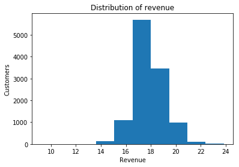

```python
plt.hist(np.log1p(train.loc[train['totals.transactionRevenue'].isna() == False, 'totals.transactionRevenue']));
plt.title('Distribution of revenue');
plt.xlabel('Revenue')
plt.ylabel('Customers')
```

Here we can see the distribution of transaction revenue. But it would be more useful to see a distribution of total revenue per user.

```
Text(0,0.5,'Number of costumers')
```

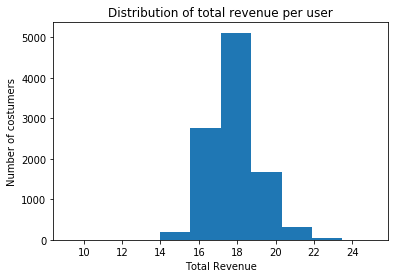

```python
grouped = train.groupby('fullVisitorId')['totals.transactionRevenue'].sum().reset_index()
grouped = grouped.loc[grouped['totals.transactionRevenue'].isna() == False]
plt.hist(np.log(grouped.loc[grouped['totals.transactionRevenue'] > 0, 'totals.transactionRevenue']));
plt.title('Distribution of total revenue per user');
plt.xlabel('Total Revenue')
plt.ylabel('Number of costumers')
```

This two graphs are somehow very similar.

```python
counts = train.loc[train['totals.transactionRevenue'] > 0, 'fullVisitorId'].value_counts()
print('There are {0} paying users ({1} total) in train data.'.format(len(counts), train['fullVisitorId'].nunique()))
print('{0} users ({1:.4f}% of paying) have 1 paid transaction.'.format(np.sum(counts == 1), 100 * np.sum(counts == 1) / len(counts)))
print('{0} users ({1:.4f}% of paying) have 2 paid transaction.'.format(np.sum(counts == 2), 100 * np.sum(counts == 2) / len(counts)))
print('')
print('Count of non-zero transactions per user:')
counts.head(10)
```

```
There are 10114 paying users (723803 total) in train data.
9208 users (91.0421% of paying) have 1 paid transaction.
671 users (6.6344% of paying) have 2 paid transaction.

Count of non-zero transactions per user:
```

```
7813149961404844386    31
1957458976293878100    16
4984366501121503466    16
6760732402251466726    13
608915197735218105     12
2402527199731150932    11
7311242886083854158    11
9089132392240687728    10
8197879643797712877    10
9029794295932939024     9
Name: fullVisitorId, dtype: int64
```

Most paying users made only 1 transaction, but there are several users, who had a lot of transactions.

### Where does the paying users come from?

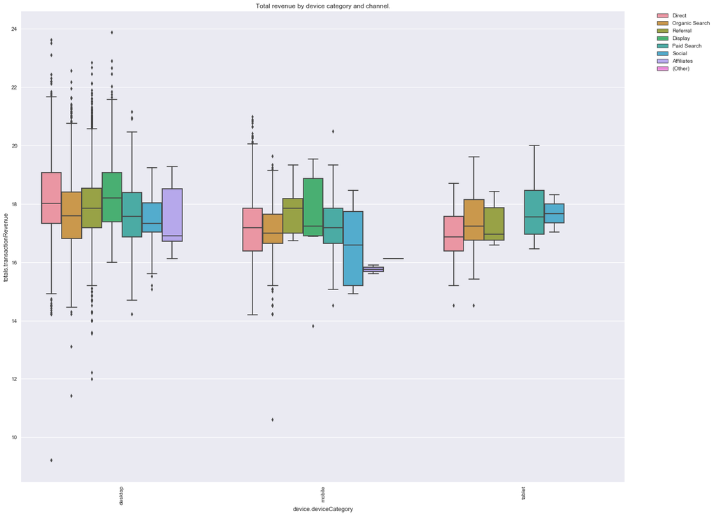

```python
train['totals.transactionRevenue'] = train['totals.transactionRevenue'].fillna(0)
train['totals.transactionRevenue'] = np.log1p(train['totals.transactionRevenue'])
sns.set(rc={'figure.figsize':(20, 16)})
train_ = train.loc[train['totals.transactionRevenue'] > 0.0]
sns.boxplot(x="device.deviceCategory", y="totals.transactionRevenue", hue="channelGrouping",  data=train_)
plt.title("Total revenue by device category and channel.");
plt.xticks(rotation='vertical')
plt.legend(bbox_to_anchor=(1.05, 1), loc=2, borderaxespad=0.)
plt.show()
```

We can see that the desktop is the prefered devices for our users to make purchases and that the least profitable channels are Affilate and Others.

### When are they buying?

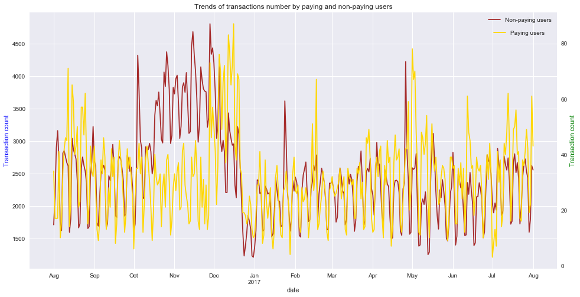

```python
fig, ax1 = plt.subplots(figsize=(16, 8))
plt.title("Trends of transactions number by paying and non-paying users");
train.groupby(['date'])['totals.transactionRevenue'].count().plot(color='brown')
ax1.set_ylabel('Transaction count', color='b')
plt.legend(['Non-paying users'])
ax2 = ax1.twinx()
train_.groupby(['date'])['totals.transactionRevenue'].count().plot(color='gold')
ax2.set_ylabel('Transaction count', color='g')
plt.legend(['Paying users'], loc=(0.875, 0.9))
plt.grid(False)
```

## Devices

```
Mean revenue per transaction
```

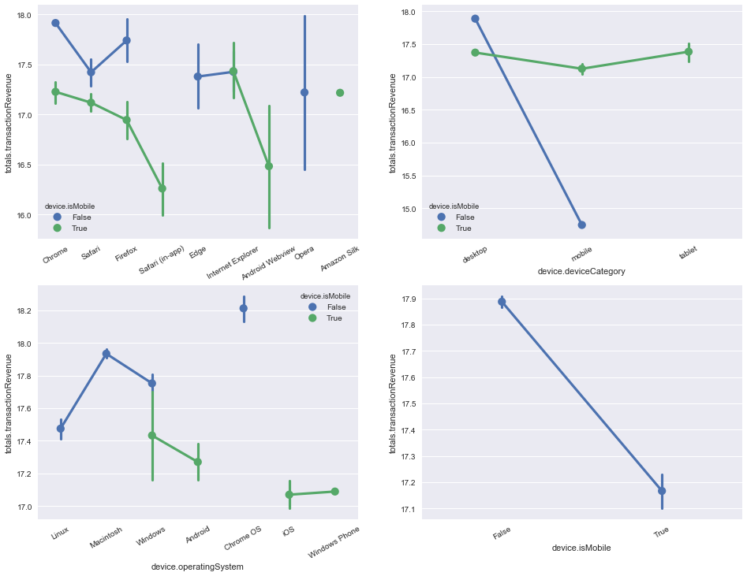

```python
fig, ax = plt.subplots(2, 2, figsize = (16, 12))
print('Mean revenue per transaction')
sns.pointplot(x="device.browser", y="totals.transactionRevenue", hue="device.isMobile", data=train_, ax = ax[0, 0]);
sns.pointplot(x="device.deviceCategory", y="totals.transactionRevenue", hue="device.isMobile", data=train_, ax = ax[0, 1]);
sns.pointplot(x="device.operatingSystem", y="totals.transactionRevenue", hue="device.isMobile", data=train_, ax = ax[1, 0]);
sns.pointplot(x="device.isMobile", y="totals.transactionRevenue", data=train_, ax = ax[1, 1]);
ax[0, 0].xaxis.set_tick_params(rotation=30);
ax[0, 1].xaxis.set_tick_params(rotation=30);
ax[1, 0].xaxis.set_tick_params(rotation=30);
ax[1, 1].xaxis.set_tick_params(rotation=30);
```

Chrome OS and Macintosh are clear winners here.

## geoNetwork

```python
def show_count_sum(df, col):
    return df.groupby(col).agg({'totals.transactionRevenue': ['count', 'mean']}).sort_values(('totals.transactionRevenue', 'count'), ascending=False).head()
show_count_sum(train_, 'geoNetwork.subContinent')
```

| geoNetwork.subContinent | totals.transactionRevenue count | totals.transactionRevenue mean |
| --- | --- | --- |
| Northern America | 11143 | 17.816635 |
| South America | 98 | 18.343874 |
| Eastern Asia | 59 | 18.058084 |
| Southeast Asia | 32 | 18.250344 |
| Western Europe | 30 | 17.874502 |

Is not a surprise that most of the revenue comes from North America.

### Which regions?

```python
show_count_sum(train_.loc[train_['geoNetwork.subContinent'] == 'Northern America'], 'geoNetwork.region')
```

| geoNetwork.region | totals.transactionRevenue count | totals.transactionRevenue mean |
| --- | --- | --- |
| not available in demo dataset | 4396 | 17.697129 |
| California | 3297 | 17.803831 |
| New York | 1500 | 18.022524 |
| Illinois | 422 | 18.306118 |
| Washington | 335 | 17.772531 |

California and New York are the states with more transactions, that we know of.

### Traffic source

```
Text(0.5,0,'SOURCE')
```

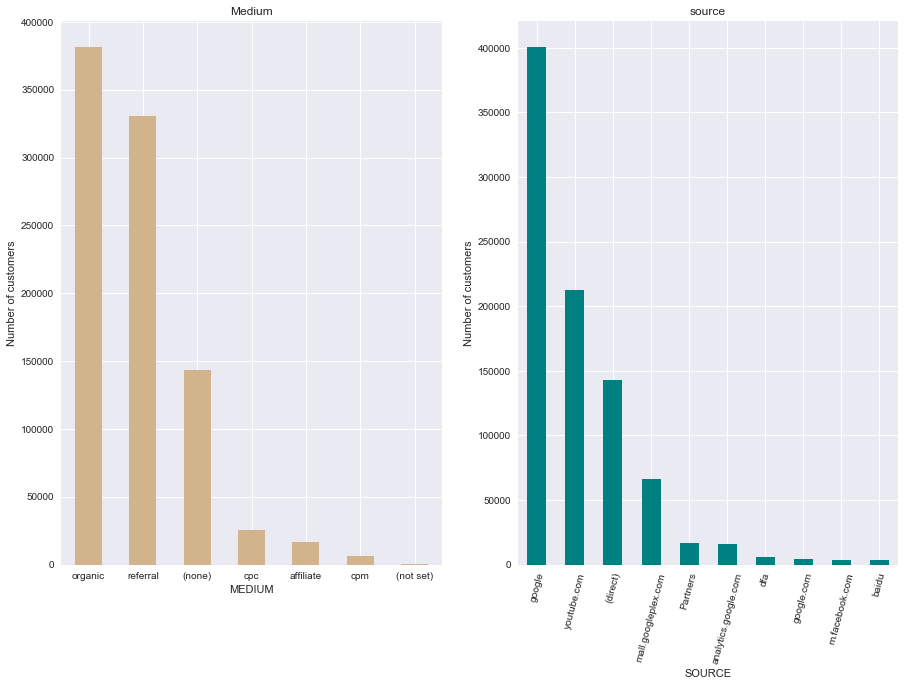

```python
fig,axes = plt.subplots(1,2,figsize=(15,10))

train["trafficSource.medium"].value_counts().plot(kind="bar",ax = axes[0],title="Medium",rot=0,color="tan")

train["trafficSource.source"].value_counts().head(10).plot(kind="bar",ax=axes[1],title="source",rot=75,color="teal")

axes[0].set_ylabel('Number of customers')
axes[1].set_ylabel('Number of customers')

axes[0].set_xlabel('MEDIUM')
axes[1].set_xlabel('SOURCE')
```

```
Text(0.5,0,'KEYWORDS (dropping NA)')
```

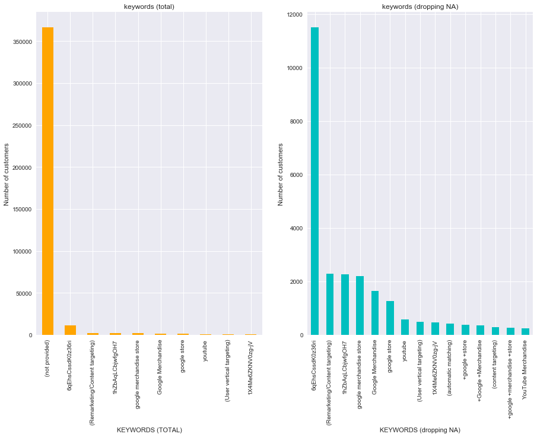

```python
fig,axes = plt.subplots(1,2,figsize=(15,10))
train["trafficSource.keyword"].value_counts().head(10).plot(kind="bar",ax=axes[0], title="keywords (total)",color="orange")
train[train["trafficSource.keyword"] != "(not provided)"]["trafficSource.keyword"].value_counts().head(15).plot(kind="bar",ax=axes[1],title="keywords (dropping NA)",color="c")

axes[0].set_ylabel('Number of customers')
axes[1].set_ylabel('Number of customers')

axes[0].set_xlabel('KEYWORDS (TOTAL)')
axes[1].set_xlabel('KEYWORDS (dropping NA)')
```

### Totals

```
Text(0,0.5,'Number of Customers')
```

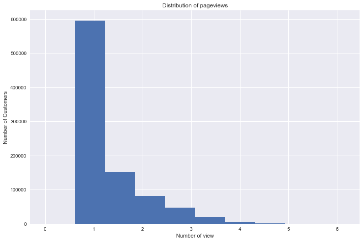

```python
plt.figure(figsize=(12, 8))
plt.title('Distribution of pageviews');
plt.hist(np.log1p(train['totals.pageviews'].fillna(0)));
plt.xlabel('Number of view')
plt.ylabel('Number of Customers')
```

```
Text(0,0.5,'Number of Customers')
```

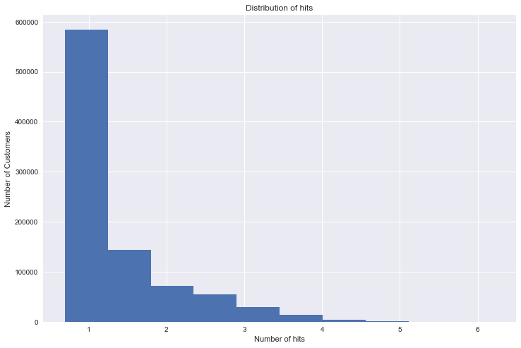

```python
plt.figure(figsize=(12, 8))
plt.title('Distribution of hits');
plt.hist(np.log1p(train['totals.hits'].fillna(0)));
plt.xlabel('Number of hits')
plt.ylabel('Number of Customers')
```

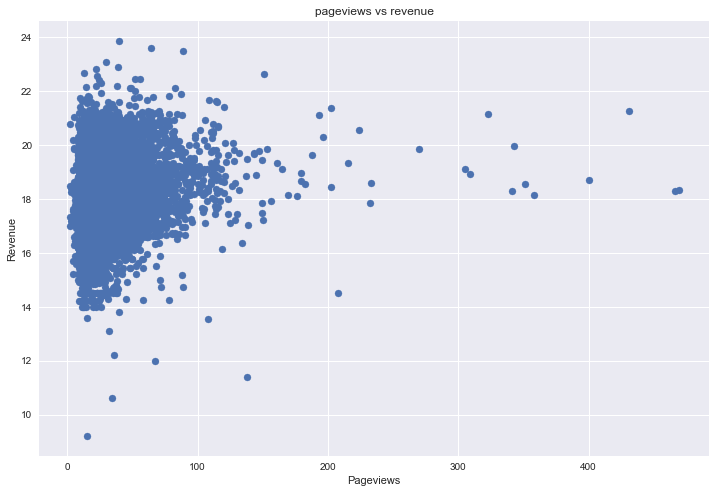

```python
plt.figure(figsize=(12, 8))
plt.title('pageviews vs revenue');
plt.scatter(train_['totals.pageviews'], train_['totals.transactionRevenue']);
plt.xlabel('Pageviews');
plt.ylabel('Revenue');
```

# Feature engineering

Let clear some memory

```python
del grouped, counts, train_
```

## Time bases features

Let us get some important information out of the date, like month, week, day and week of year. And check the unique user count for each of them.

```python
# time based
train['month'] = train['date'].dt.month
train['day'] = train['date'].dt.day
train['weekday'] = train['date'].dt.weekday
train['weekofyear'] = train['date'].dt.weekofyear

#counts per month week and week of year
train['month_unique_user_count'] = train.groupby('month')['fullVisitorId'].transform('nunique')
train['day_unique_user_count'] = train.groupby('day')['fullVisitorId'].transform('nunique')
train['weekday_unique_user_count'] = train.groupby('weekday')['fullVisitorId'].transform('nunique')
train['weekofyear_unique_user_count'] = train.groupby('weekofyear')['fullVisitorId'].transform('nunique')
#Same for test
test['month'] = test['date'].dt.month
test['day'] = test['date'].dt.day
test['weekday'] = test['date'].dt.weekday
test['weekofyear'] = test['date'].dt.weekofyear
#Same for test
test['month_unique_user_count'] = test.groupby('month')['fullVisitorId'].transform('nunique')
test['day_unique_user_count'] = test.groupby('day')['fullVisitorId'].transform('nunique')
test['weekday_unique_user_count'] = test.groupby('weekday')['fullVisitorId'].transform('nunique')
test['weekofyear_unique_user_count'] = test.groupby('weekofyear')['fullVisitorId'].transform('nunique')
```

## Device based features.

We are just gonna merge some fields into one to get rid of some colums.

```python
#combining browser blobs into one feature
train['browser_category'] = train['device.browser'] + '_' + train['device.deviceCategory']
train['browser_operatingSystem'] = train['device.browser'] + '_' + train['device.operatingSystem']

test['browser_category'] = test['device.browser'] + '_' + test['device.deviceCategory']
test['browser_operatingSystem'] = test['device.browser'] + '_' + test['device.operatingSystem']

train['source_country'] = train['trafficSource.source'] + '_' + train['geoNetwork.country']
test['source_country'] = test['trafficSource.source'] + '_' + test['geoNetwork.country']
```

## Numerical features and log transformation

```python
#getting natural log for certain features
train['visitNumber'] = np.log1p(train['visitNumber'])
test['visitNumber'] = np.log1p(test['visitNumber'])

train['totals.hits'] = np.log1p(train['totals.hits'])
test['totals.hits'] = np.log1p(test['totals.hits'].astype(int))

train['totals.pageviews'] = np.log1p(train['totals.pageviews'].fillna(0))
test['totals.pageviews'] = np.log1p(test['totals.pageviews'].astype(float).fillna(0))
#gettin suum, count and week of hits per network domain
train['sum_pageviews_per_network_domain'] = train.groupby('geoNetwork.networkDomain')['totals.pageviews'].transform('sum')
train['count_pageviews_per_network_domain'] = train.groupby('geoNetwork.networkDomain')['totals.pageviews'].transform('count')
train['mean_pageviews_per_network_domain'] = train.groupby('geoNetwork.networkDomain')['totals.pageviews'].transform('mean')
train['sum_hits_per_network_domain'] = train.groupby('geoNetwork.networkDomain')['totals.hits'].transform('sum')
train['count_hits_per_network_domain'] = train.groupby('geoNetwork.networkDomain')['totals.hits'].transform('count')
train['mean_hits_per_network_domain'] = train.groupby('geoNetwork.networkDomain')['totals.hits'].transform('mean')

test['sum_pageviews_per_network_domain'] = test.groupby('geoNetwork.networkDomain')['totals.pageviews'].transform('sum')
test['count_pageviews_per_network_domain'] = test.groupby('geoNetwork.networkDomain')['totals.pageviews'].transform('count')
test['mean_pageviews_per_network_domain'] = test.groupby('geoNetwork.networkDomain')['totals.pageviews'].transform('mean')
test['sum_hits_per_network_domain'] = test.groupby('geoNetwork.networkDomain')['totals.hits'].transform('sum')
test['count_hits_per_network_domain'] = test.groupby('geoNetwork.networkDomain')['totals.hits'].transform('count')
test['mean_hits_per_network_domain'] = test.groupby('geoNetwork.networkDomain')['totals.hits'].transform('mean')
#hits mean and sum of hits per day
train['mean_hits_per_day'] = train.groupby(['day'])['totals.hits'].transform('mean')
train['sum_hits_per_day'] = train.groupby(['day'])['totals.hits'].transform('sum')
test['mean_hits_per_day'] = test.groupby(['day'])['totals.hits'].transform('mean')
test['sum_hits_per_day'] = test.groupby(['day'])['totals.hits'].transform('sum')
```

```python
train['sum_pageviews_per_network_domain'] = train.groupby('geoNetwork.networkDomain')['totals.pageviews'].transform('sum')
train['count_pageviews_per_network_domain'] = train.groupby('geoNetwork.networkDomain')['totals.pageviews'].transform('count')
train['mean_pageviews_per_network_domain'] = train.groupby('geoNetwork.networkDomain')['totals.pageviews'].transform('mean')

train['sum_pageviews_per_region'] = train.groupby('geoNetwork.region')['totals.pageviews'].transform('sum')
train['count_pageviews_per_region'] = train.groupby('geoNetwork.region')['totals.pageviews'].transform('count')
train['mean_pageviews_per_region'] = train.groupby('geoNetwork.region')['totals.pageviews'].transform('mean')

test['sum_pageviews_per_network_domain'] = test.groupby('geoNetwork.networkDomain')['totals.pageviews'].transform('sum')
test['count_pageviews_per_network_domain'] = test.groupby('geoNetwork.networkDomain')['totals.pageviews'].transform('count')
test['mean_pageviews_per_network_domain'] = test.groupby('geoNetwork.networkDomain')['totals.pageviews'].transform('mean')

test['sum_pageviews_per_region'] = test.groupby('geoNetwork.region')['totals.pageviews'].transform('sum')
test['count_pageviews_per_region'] = test.groupby('geoNetwork.region')['totals.pageviews'].transform('count')
test['mean_pageviews_per_region'] = test.groupby('geoNetwork.region')['totals.pageviews'].transform('mean')
```

```python
train['sum_hits_per_network_domain'] = train.groupby('geoNetwork.networkDomain')['totals.hits'].transform('sum')
train['count_hits_per_network_domain'] = train.groupby('geoNetwork.networkDomain')['totals.hits'].transform('count')
train['mean_hits_per_network_domain'] = train.groupby('geoNetwork.networkDomain')['totals.hits'].transform('mean')

train['sum_hits_per_region'] = train.groupby('geoNetwork.region')['totals.hits'].transform('sum')
train['count_hits_per_region'] = train.groupby('geoNetwork.region')['totals.hits'].transform('count')
train['mean_hits_per_region'] = train.groupby('geoNetwork.region')['totals.hits'].transform('mean')

train['sum_hits_per_country'] = train.groupby('geoNetwork.country')['totals.hits'].transform('sum')
train['count_hits_per_country'] = train.groupby('geoNetwork.country')['totals.hits'].transform('count')
train['mean_hits_per_country'] = train.groupby('geoNetwork.country')['totals.hits'].transform('mean')

test['sum_hits_per_network_domain'] = test.groupby('geoNetwork.networkDomain')['totals.hits'].transform('sum')
test['count_hits_per_network_domain'] = test.groupby('geoNetwork.networkDomain')['totals.hits'].transform('count')
test['mean_hits_per_network_domain'] = test.groupby('geoNetwork.networkDomain')['totals.hits'].transform('mean')

test['sum_hits_per_region'] = test.groupby('geoNetwork.region')['totals.hits'].transform('sum')
test['count_hits_per_region'] = test.groupby('geoNetwork.region')['totals.hits'].transform('count')
test['mean_hits_per_region'] = test.groupby('geoNetwork.region')['totals.hits'].transform('mean')

test['sum_hits_per_country'] = test.groupby('geoNetwork.country')['totals.hits'].transform('sum')
test['count_hits_per_country'] = test.groupby('geoNetwork.country')['totals.hits'].transform('count')
test['mean_hits_per_country'] = test.groupby('geoNetwork.country')['totals.hits'].transform('mean')
```

```python
train['user_pageviews_sum'] = train.groupby('fullVisitorId')['totals.pageviews'].transform('sum')
train['user_hits_sum'] = train.groupby('fullVisitorId')['totals.hits'].transform('sum')
test['user_pageviews_sum'] = test.groupby('fullVisitorId')['totals.pageviews'].transform('sum')
test['user_hits_sum'] = test.groupby('fullVisitorId')['totals.hits'].transform('sum')

train['user_pageviews_count'] = train.groupby('fullVisitorId')['totals.pageviews'].transform('count')
train['user_hits_count'] = train.groupby('fullVisitorId')['totals.hits'].transform('count')
test['user_pageviews_count'] = test.groupby('fullVisitorId')['totals.pageviews'].transform('count')
test['user_hits_count'] = test.groupby('fullVisitorId')['totals.hits'].transform('count')

train['user_pageviews_sum_to_mean'] = train['user_pageviews_sum'] / train['user_pageviews_sum'].mean()
train['user_hits_sum_to_mean'] = train['user_hits_sum'] / train['user_hits_sum'].mean()
test['user_pageviews_sum_to_mean'] = test['user_pageviews_sum'] / test['user_pageviews_sum'].mean()
test['user_hits_sum_to_mean'] = test['user_hits_sum'] / test['user_hits_sum'].mean()
```

```python
train['user_pageviews_to_region'] = train['user_pageviews_sum'] / train['mean_pageviews_per_region']
train['user_hits_to_region'] = train['user_hits_sum'] / train['mean_hits_per_region']

test['user_pageviews_to_region'] = test['user_pageviews_sum'] / test['mean_pageviews_per_region']
test['user_hits_to_region'] = test['user_hits_sum'] / test['mean_hits_per_region']
```

```python
#checking our final columns after feature engeniring
train.columns
```

```
Index(['channelGrouping', 'date', 'fullVisitorId', 'sessionId', 'visitId',
       'visitNumber', 'visitStartTime', 'device.browser',
       'device.deviceCategory', 'device.isMobile', 'device.operatingSystem',
       'geoNetwork.city', 'geoNetwork.continent', 'geoNetwork.country',
       'geoNetwork.metro', 'geoNetwork.networkDomain', 'geoNetwork.region',
       'geoNetwork.subContinent', 'totals.bounces', 'totals.hits',
       'totals.newVisits', 'totals.pageviews', 'totals.transactionRevenue',
       'trafficSource.adContent',
       'trafficSource.adwordsClickInfo.adNetworkType',
       'trafficSource.adwordsClickInfo.gclId',
       'trafficSource.adwordsClickInfo.isVideoAd',
       'trafficSource.adwordsClickInfo.page',
       'trafficSource.adwordsClickInfo.slot', 'trafficSource.campaign',
       'trafficSource.isTrueDirect', 'trafficSource.keyword',
       'trafficSource.medium', 'trafficSource.referralPath',
       'trafficSource.source', 'month', 'day', 'weekday', 'weekofyear',
       'month_unique_user_count', 'day_unique_user_count',
       'weekday_unique_user_count', 'weekofyear_unique_user_count',
       'browser_category', 'browser_operatingSystem', 'source_country',
       'sum_pageviews_per_network_domain',
       'count_pageviews_per_network_domain',
       'mean_pageviews_per_network_domain', 'sum_hits_per_network_domain',
       'count_hits_per_network_domain', 'mean_hits_per_network_domain',
       'mean_hits_per_day', 'sum_hits_per_day', 'sum_pageviews_per_region',
       'count_pageviews_per_region', 'mean_pageviews_per_region',
       'sum_hits_per_region', 'count_hits_per_region', 'mean_hits_per_region',
       'sum_hits_per_country', 'count_hits_per_country',
       'mean_hits_per_country', 'user_pageviews_sum', 'user_hits_sum',
       'user_pageviews_count', 'user_hits_count', 'user_pageviews_sum_to_mean',
       'user_hits_sum_to_mean', 'user_pageviews_to_region',
       'user_hits_to_region'],
      dtype='object')
```

```python
#list of numerical columns
num_cols = ['visitNumber', 'totals.hits', 'totals.pageviews', 'month_unique_user_count', 'day_unique_user_count', 'mean_hits_per_day'
           'sum_pageviews_per_network_domain', 'sum_hits_per_network_domain', 'count_hits_per_network_domain', 'sum_hits_per_region',
           'sum_hits_per_day', 'count_pageviews_per_network_domain', 'mean_pageviews_per_network_domain', 'weekday_unique_user_count',
           'sum_pageviews_per_region', 'count_pageviews_per_region', 'mean_pageviews_per_region', 'user_pageviews_count', 'user_hits_count',
           'count_hits_per_region', 'mean_hits_per_region', 'user_pageviews_sum', 'user_hits_sum', 'user_pageviews_sum_to_mean',
            'user_hits_sum_to_mean', 'user_pageviews_to_region', 'user_hits_to_region', 'mean_pageviews_per_network_domain',
           'mean_hits_per_network_domain']
#Creating a list of columns we do not want to use anymore
no_use = ["visitNumber", "date", "fullVisitorId", "sessionId", "visitId", "visitStartTime",
          'totals.transactionRevenue', 'trafficSource.referralPath','trafficSource.adContent',
       'trafficSource.adwordsClickInfo.adNetworkType',
       'trafficSource.adwordsClickInfo.gclId',
       'trafficSource.adwordsClickInfo.isVideoAd',
       'trafficSource.adwordsClickInfo.page',
       'trafficSource.adwordsClickInfo.slot', 'trafficSource.campaign',
       'trafficSource.isTrueDirect','browser_category', 'browser_operatingSystem', 'source_country',
       'sum_pageviews_per_network_domain',
       'count_pageviews_per_network_domain',
       'mean_pageviews_per_network_domain', 'sum_hits_per_network_domain',
       'count_hits_per_network_domain', 'mean_hits_per_network_domain',
       'mean_hits_per_day', 'sum_hits_per_day', 'sum_pageviews_per_region',
       'count_pageviews_per_region', 'mean_pageviews_per_region',
       'sum_hits_per_region', 'count_hits_per_region', 'mean_hits_per_region',
       'sum_hits_per_country', 'count_hits_per_country',
       'mean_hits_per_country', 'user_pageviews_sum', 'user_hits_sum',
       'user_pageviews_count', 'user_hits_count', 'user_pageviews_sum_to_mean',
       'user_hits_sum_to_mean', 'user_pageviews_to_region',
       'user_hits_to_region']
cat_cols = [col for col in train.columns if col not in num_cols and col not in no_use]
```

## Encoding categorical features

```python
#Importing the encoder
from sklearn.preprocessing import LabelEncoder

#Creating a loop
for col in cat_cols:
    print(col)
    #Creating an instance of the encoder
    lbl = LabelEncoder()
    #fitting the columns to encode for both sets
    lbl.fit(list(train[col].values.astype('str')) + list(test[col].values.astype('str')))
    train[col] = lbl.transform(list(train[col].values.astype('str')))
    test[col] = lbl.transform(list(test[col].values.astype('str')))
```

```
channelGrouping
device.browser
device.deviceCategory
device.isMobile
device.operatingSystem
geoNetwork.city
geoNetwork.continent
geoNetwork.country
geoNetwork.metro
geoNetwork.networkDomain
geoNetwork.region
geoNetwork.subContinent
totals.bounces
totals.newVisits
trafficSource.keyword
trafficSource.medium
trafficSource.source
month
day
weekday
weekofyear
weekofyear_unique_user_count
```

```python
train.head()
```

|  | channelGrouping | date | fullVisitorId | sessionId | visitId | visitNumber | visitStartTime | device.browser | device.deviceCategory | device.isMobile | ... | count_hits_per_country | mean_hits_per_country | user_pageviews_sum | user_hits_sum | user_pageviews_count | user_hits_count | user_pageviews_sum_to_mean | user_hits_sum_to_mean | user_pageviews_to_region | user_hits_to_region |
| --- | --- | --- | --- | --- | --- | --- | --- | --- | --- | --- | --- | --- | --- | --- | --- | --- | --- | --- | --- | --- | --- |
| 0 | 4 | 2016-09-02 | 1131660440785968503 | 1131660440785968503_1472830385 | 1472830385 | 0.693147 | 1472830385 | 35 | 0 | 0 | ... | 20522 | 0.901934 | 0.693147 | 0.693147 | 1 | 1 | 0.190445 | 0.181993 | 0.797648 | 0.790633 |
| 1 | 4 | 2016-09-02 | 377306020877927890 | 377306020877927890_1472880147 | 1472880147 | 0.693147 | 1472880147 | 43 | 0 | 0 | ... | 12698 | 1.189617 | 0.693147 | 0.693147 | 1 | 1 | 0.190445 | 0.181993 | 0.591788 | 0.569391 |
| 2 | 4 | 2016-09-02 | 3895546263509774583 | 3895546263509774583_1472865386 | 1472865386 | 0.693147 | 1472865386 | 35 | 0 | 0 | ... | 11658 | 1.073835 | 0.693147 | 0.693147 | 1 | 1 | 0.190445 | 0.181993 | 0.669070 | 0.648116 |
| 3 | 4 | 2016-09-02 | 4763447161404445595 | 4763447161404445595_1472881213 | 1472881213 | 0.693147 | 1472881213 | 79 | 0 | 0 | ... | 9273 | 1.015221 | 0.693147 | 0.693147 | 1 | 1 | 0.190445 | 0.181993 | 0.591788 | 0.569391 |
| 4 | 4 | 2016-09-02 | 27294437909732085 | 27294437909732085_1472822600 | 1472822600 | 1.098612 | 1472822600 | 35 | 1 | 1 | ... | 37393 | 1.070902 | 1.386294 | 1.386294 | 2 | 2 | 0.380890 | 0.363985 | 1.183576 | 1.138782 |

5 rows × 71 columns

```python
#lets sort the values by date
train = train.sort_values('date')
#lets create our final features Data frame and store it in the X Variable
X = train.drop(no_use, axis=1)\
#Storing our target in the y Variable
y = train['totals.transactionRevenue']
#dropping useless columns in the test set
X_test = test.drop([col for col in no_use if col in test.columns], axis=1)
```

```python
feature_summary(X)
```

```
DataFrame shape
rows: 903653
cols: 27
```

|  | Null | Unique_Count | Data_type | Max/Min | Mean | Std | Skewness | Sample_values |
| --- | --- | --- | --- | --- | --- | --- | --- | --- |
| channelGrouping | 0 | 8 | int64 | 7/0 | 4.632267 | 1.774791 | -0.051328 | [2, 6, 3, 5, 4, 7, 1, 0] |
| device.browser | 0 | 54 | int64 | 117/0 | 44.014666 | 15.389741 | 1.222764 | [35, 72, 43, 47, 67, 79, 51, 42, 73, 82, 48, 6... |
| device.deviceCategory | 0 | 3 | int64 | 2/0 | 0.298370 | 0.526058 | 1.554285 | [0, 1, 2] |
| device.isMobile | 0 | 2 | int64 | 1/0 | 0.264618 | 0.441130 | 1.067179 | [0, 1] |
| device.operatingSystem | 0 | 20 | int64 | 23/0 | 12.949865 | 8.159630 | -0.163978 | [7, 20, 3, 23, 1, 6, 0, 21, 4, 16, 10, 2, 22, ... |
| geoNetwork.city | 0 | 649 | int64 | 955/0 | 740.380483 | 302.648488 | -1.187735 | [955, 346, 540, 636, 749, 376, 829, 360, 165, ... |
| geoNetwork.continent | 0 | 6 | int64 | 5/0 | 2.716869 | 0.885558 | 0.530961 | [3, 2, 4, 1, 5, 0] |
| geoNetwork.country | 0 | 222 | int64 | 227/0 | 163.035326 | 69.196953 | -0.854388 | [102, 223, 218, 28, 204, 210, 132, 222, 100, 9... |
| geoNetwork.metro | 0 | 94 | int64 | 122/0 | 85.871039 | 50.605625 | -0.958246 | [122, 0, 100, 46, 93, 75, 6, 30, 61, 60, 10, 1... |
| geoNetwork.networkDomain | 0 | 28064 | int64 | 41980/0 | 18911.072901 | 16539.152347 | 0.066383 | [16623, 38725, 0, 4983, 12173, 29216, 39326, 5... |
| geoNetwork.region | 0 | 376 | int64 | 482/0 | 352.329262 | 173.492619 | -0.822720 | [482, 168, 73, 192, 430, 87, 174, 194, 126, 0,... |
| geoNetwork.subContinent | 0 | 23 | int64 | 22/0 | 13.310106 | 4.678611 | -0.140625 | [6, 16, 12, 15, 21, 3, 19, 18, 7, 5, 1, 13, 22... |
| totals.bounces | 0 | 2 | int64 | 1/0 | 0.501324 | 0.499999 | -0.005296 | [0, 1] |
| totals.hits | 0 | 274 | float64 | 6.22/0.69 | 1.265608 | 0.785061 | 1.550467 | [0.6931471805599453, 2.4849066497880004, 2.564... |
| totals.newVisits | 0 | 2 | int64 | 1/0 | 0.221980 | 0.415578 | 1.337994 | [0, 1] |
| totals.pageviews | 0 | 214 | float64 | 6.15/0.0 | 1.215714 | 0.712294 | 1.529672 | [0.6931471805599453, 2.302585092994046, 2.4849... |
| trafficSource.keyword | 0 | 3660 | int64 | 5391/0 | 1897.047624 | 1640.605290 | -0.259653 | [3327, 53, 3514, 11, 7, 1301, 65, 1300, 1299, ... |
| trafficSource.medium | 0 | 7 | int64 | 6/0 | 4.456896 | 2.076703 | -1.447162 | [0, 6, 4, 3, 5, 2, 1] |
| trafficSource.source | 0 | 380 | int64 | 499/0 | 254.317229 | 166.515464 | 0.159096 | [0, 358, 171, 208, 497, 352, 225, 417, 219, 44... |
| month | 0 | 12 | int64 | 11/0 | 5.235452 | 3.500297 | 0.154258 | [10, 11, 1, 2, 3, 0, 4, 5, 6, 7, 8, 9] |
| day | 0 | 31 | int64 | 30/0 | 14.828239 | 8.944950 | 0.034021 | [0, 11, 22, 25, 26, 27, 28, 29, 30, 1, 2, 3, 4... |
| weekday | 0 | 7 | int64 | 6/0 | 2.735183 | 1.929072 | 0.181619 | [0, 1, 2, 3, 4, 5, 6] |
| weekofyear | 0 | 52 | int64 | 51/0 | 26.883834 | 14.667590 | -0.200676 | [24, 25, 26, 27, 28, 29, 30, 31, 32, 34, 35, 3... |
| month_unique_user_count | 0 | 12 | int64 | 99734/51713 | 66080.339115 | 15965.581673 | 1.177702 | [64591, 60357, 85823, 99734, 64909, 53458, 517... |
| day_unique_user_count | 0 | 31 | int64 | 29802/16357 | 26968.669857 | 1916.497753 | -3.252064 | [29802, 26792, 26920, 28614, 28948, 26919, 264... |
| weekday_unique_user_count | 0 | 7 | int64 | 129799/89687 | 117784.947385 | 15147.328076 | -1.055148 | [125177, 129631, 129799, 126473, 114519, 89687... |
| weekofyear_unique_user_count | 0 | 52 | int64 | 91/0 | 39.542439 | 28.512783 | 0.570171 | [68, 38, 40, 25, 41, 23, 34, 36, 32, 66, 59, 8... |

```python
y.head()
```

```
538448    0.0
538277    0.0
538278    0.0
538279    0.0
538280    0.0
Name: totals.transactionRevenue, dtype: float64
```

# Splitting the data for model testing.

```python
#Splitting data for model testing
from sklearn.cross_validation import train_test_split


X_train, X_test, y_train, y_test = train_test_split(X,
                                                    y,
                                                    test_size = 0.2,
                                                    random_state = 0)


print("Training set has {} samples.".format(X_train.shape[0]))
print("Testing set has {} samples.".format(X_test.shape[0]))
```

```
Training set has 722922 samples.
Testing set has 180731 samples.
```

```python
#Creating sample variables to fit in our evaluation function.
X_train_sample=X_train
X_test_sample=X_test
y_train_sample=y_train
y_test_sample=y_test
```

```python
#We will test a naive prediction that always guesses 1 and check the results
naive_prediction = [1 for i in range(len(y_test_sample))]
true_values = y_test_sample

#importing our metrics
from sklearn.metrics import mean_absolute_error
from sklearn.metrics import mean_squared_error
#creating and variable for each
mse = mean_squared_error(true_values, naive_prediction)
mas =mean_absolute_error(true_values, naive_prediction)



print("Naive Predictor: [mas: {:.4f}, mse: {:.4f}]".format(mas, mse))
```

```
Naive Predictor: [mas: 1.1977, mse: 4.5342]
```

```python
#Evaluation function
def train_predict(learner, sample_size, X_train, y_train, X_test, y_test):
    '''
    inputs:
       - learner: the learning algorithm to be trained and predicted on
       - sample_size: the size of samples (number) to be drawn from training set
       - X_train: features training set
       - y_train: income training set
       - X_test: features testing set
       - y_test: income testing set
    '''
    #Dictionary with the metrics and scores
    results = {}


    start = time() # Get start time
    learner = learner.fit(X_train[:sample_size],y_train[:sample_size])
    end = time() # Get end time


    results['train_time'] = end - start

    start = time() # Get start time
    predictions_test = learner.predict(X_test)
    predictions_train = learner.predict(X_train[:300])
    end = time() # Get end time


    results['pred_time'] = end-start


    results['abs_train'] = mean_absolute_error(y_train[:300], predictions_train)


    results['abs_test'] = mean_absolute_error(y_test, predictions_test)

    results['mse_train'] = mean_squared_error(y_train[:300], predictions_train)


    results['mse_test'] = mean_squared_error(y_test, predictions_test)


    print("{} trained on {} samples.".format(learner.__class__.__name__, sample_size))


    return results
```

```python
#Importing the models to be tested
from sklearn.ensemble import RandomForestRegressor
from sklearn.ensemble import AdaBoostRegressor
from sklearn.ensemble import GradientBoostingRegressor
from time import time
!pip install xgboost
import xgboost as xgb
from xgboost import XGBRegressor
```

```
You are using pip version 18.0, however version 18.1 is available.
```

# Model testing

```python
#Creating an instance for each model
clf_A =XGBRegressor()
clf_B = AdaBoostRegressor()
clf_C = GradientBoostingRegressor()

#Creating several samples of data to test
samples_100 = len(y_train)
samples_10 = int(0.1*len(y_train))
samples_1 = int(0.01*len(y_train))

#Iterating through each model and saving the results in a dictonary
results = {}
for clf in [clf_A, clf_B, clf_C]:
    clf_name = clf.__class__.__name__
    results[clf_name] = {}
    for i, samples in enumerate([samples_1, samples_10, samples_100]):
        results[clf_name][i] = \
        train_predict(clf, samples, X_train_sample, y_train_sample, X_test_sample, y_test_sample)
```

```
XGBRegressor trained on 7229 samples.
XGBRegressor trained on 72292 samples.
XGBRegressor trained on 722922 samples.
AdaBoostRegressor trained on 7229 samples.
AdaBoostRegressor trained on 72292 samples.
AdaBoostRegressor trained on 722922 samples.
GradientBoostingRegressor trained on 7229 samples.
GradientBoostingRegressor trained on 72292 samples.
GradientBoostingRegressor trained on 722922 samples.
```

# Results

```python
print(results['XGBRegressor'][2])
```

```
{'train_time': 86.75150752067566, 'pred_time': 0.39052319526672363, 'abs_train': 0.44609575379132566, 'abs_test': 0.3180000686503042, 'mse_train': 4.572619817430659, 'mse_test': 2.6713788629428654}
```

```python
print(results['GradientBoostingRegressor'][2])
```

```
{'train_time': 127.91423487663269, 'pred_time': 0.2187333106994629, 'abs_train': 0.447041643163646, 'abs_test': 0.317570308132116, 'mse_train': 4.611727140751754, 'mse_test': 2.672460094543753}
```

```python
print(results['AdaBoostRegressor'][2])
```

```
{'train_time': 26.64040207862854, 'pred_time': 0.15743732452392578, 'abs_train': 0.7314347114154952, 'abs_test': 0.7175715915004279, 'mse_train': 5.470922244734866, 'mse_test': 5.039500929524176}
```

# Bayesian Optimization

```python
#Spliting the data for Bayesian Opt
from sklearn.model_selection import train_test_split

X_train, X_test, y_train, y_test = train_test_split(X,
                         y, test_size=0.25)
#Transforming the data for the XGBoostRegressor and making some space in memory

del(X)
dtrain = xgb.DMatrix(X_train, label=y_train)
del(X_train)
dtest = xgb.DMatrix(X_test)
del(X_test)
del (y)
```

```python
#Installing the Bayesian Optimization module
!pip install bayesian-optimization
```

```
You are using pip version 18.0, however version 18.1 is available.
```

```python
#Importing the module and the metrics
from bayes_opt import BayesianOptimization
from sklearn.metrics import mean_squared_error
```

```python
#Create an evaluaations function with all the parameters to tune
def xgb_evaluate(max_depth,
          gamma,
          min_child_weight,
          max_delta_step,
          subsample,
          colsample_bytree,
                eta):
    params =  {
              'max_depth' : int(max_depth),
              'gamma' : gamma,
              'eta' : eta,
              'eval_metric': 'rmse',
              'subsample' : max(min(subsample, 1), 0),
              'colsample_bytree' : max(min(colsample_bytree, 1), 0),
              'min_child_weight' : min_child_weight,
              'max_delta_step' : int(max_delta_step),
              'seed' : 1001
              }
    # Used around 1000 boosting rounds in the full model
    cv_result = xgb.cv(params, dtrain, num_boost_round=1000, nfold=5)

    # Bayesian optimization only knows how to maximize, not minimize, so return the negative RMSE
    return -1.0 * cv_result['test-rmse-mean'].iloc[-1]
```

```python
#We should enter a tuple for each parameter, it represents the range of the testing. Try to make this range as short as possible
xgb_bo = BayesianOptimization(xgb_evaluate, {
                                     'max_depth': (3,5),
                                     'gamma': (2,5),
                                     'min_child_weight': (.5,2.0),
                                     'max_delta_step': (0.01,.5),
                                     'subsample': (0.0,1.0),
                                     'colsample_bytree' :(.1,1),
                                      'eta':(.001,.1)})
# Use the expected improvement acquisition function to handle negative numbers
# Optimally needs quite a few more initiation points and number of iterations
xgb_bo.maximize(init_points=10, n_iter=10, acq='ei')
```

[output not shown]

[output cut: 6965 more lines]

[output not shown]

# Best parameters

```python
#Accesing the best parameters calling res method
params = xgb_bo.res['max']['max_params']
params['max_depth'] = int(params['max_depth'])
params['subsample'] = int(params['subsample'])
params['subsample']=.9
print(params)
```

```
{'max_depth': 5, 'gamma': 2.0, 'min_child_weight': 2.0, 'max_delta_step': 0.5, 'subsample': 0.9, 'colsample_bytree': 1.0, 'eta': 0.1}
```

```python
params={'max_depth': 5, 'gamma': 2.0, 'min_child_weight': 2.0, 'max_delta_step': 0.5, 'subsample': 0.9, 'colsample_bytree': 1.0, 'eta': 0.1}
```

```python
# Train a new model with the best parameters from the search
model2 = xgb.train(params, dtrain, num_boost_round=1000)

# Predict on testing and training set
y_pred = model2.predict(dtest)
y_train_pred = model2.predict(dtrain)

# Report testing and training RMSE
print(np.sqrt(mean_squared_error(y_test, y_pred)))
print(np.sqrt(mean_squared_error(y_train, y_train_pred)))
```

[output not shown]

[output cut: 947 more lines]

[output not shown]

## KFold cross validation

```python
#Creating a dictionary with the best paragrams for training and adding objective and metric for cross validation

best_params={'max_depth': 5,
             'gamma': 2.0,
             'min_child_weight': 2.0,
             'max_delta_step': 0.5,
             'subsample': 0.9,
             'colsample_bytree': 1.0,
             'eta': 0.1,
             'objective':'reg:linear',
             'eval_metric':'rmse' }
```

```python
#Calling the cross validation method and tresting for 5 folds and same boosting rounds as trainig
result= xgb.cv(best_params, dtrain, num_boost_round=1000, nfold=5)
#getting the results
print (result)
```

[output not shown]

[output cut: 5009 more lines]

```
987         1.489824        0.004160        1.626163       0.015365
988         1.489636        0.004189        1.626107       0.015327
989         1.489525        0.004214        1.626092       0.015329
990         1.489395        0.004193        1.626082       0.015356
991         1.489244        0.004183        1.626088       0.015371
992         1.489131        0.004193        1.626112       0.015378
993         1.488955        0.004132        1.626132       0.015402
994         1.488873        0.004144        1.626140       0.015424
995         1.488742        0.004144        1.626123       0.015419
996         1.488652        0.004168        1.626137       0.015413
997         1.488502        0.004227        1.626155       0.015436
998         1.488374        0.004221        1.626172       0.015444
999         1.488232        0.004247        1.626205       0.015445

[1000 rows x 4 columns]
```

# Feature importance

```
Text(0,0.5,'fscore')
```

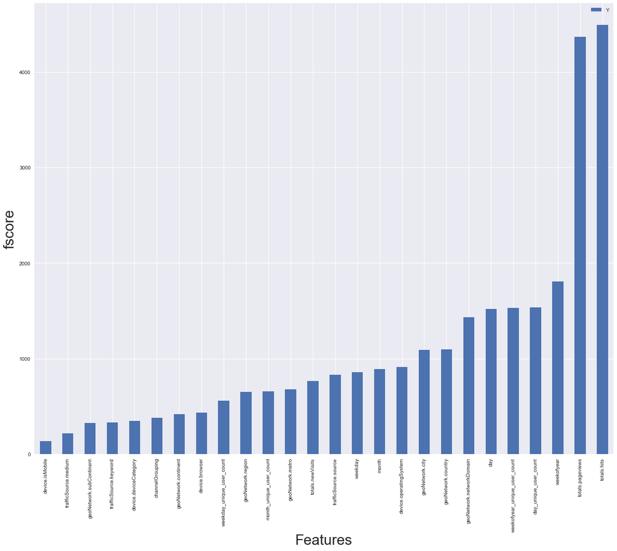

```python
#Ploting feature importance
import matplotlib.pyplot as plt
fscores = pd.DataFrame({'X': list(model2.get_fscore().keys()), 'Y': list(model2.get_fscore().values())})
fscores.sort_values(by='Y').plot.bar(x='X')
plt.xlabel('Features',fontsize=28)
plt.ylabel('fscore',fontsize=28)
```